# Case Study 1

Brady Monks

8/31/2020

## Visual 1

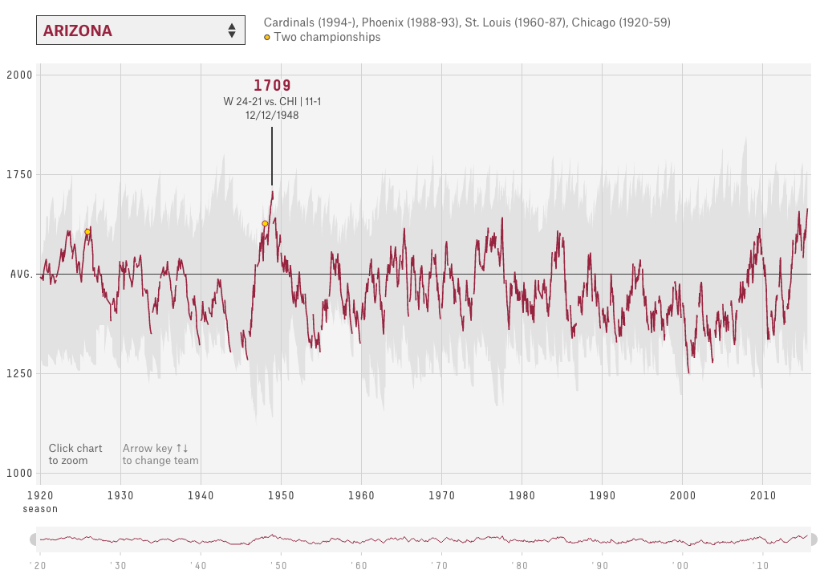

https://blog.hubspot.com/marketing/great-data-visualization-examples The visual is #4 This visual is the most impressive regarding the sheer amount of data collected for it. I enjoy how every single NFL game is represented and the axis are easily understandable. The only downfall of it is it only shows one team at a time, which makes sense regarding the amount of data, just could be hard to navigate for some.

## Visual 2

[figure not shown]

https://blog.hubspot.com/marketing/great-data-visualization-examples The visual is #7 This visual is the easiest one out of the bunch to read. There are 3 different faces that distinguish the relationship and make it quite simple. I also like how easy the table format makes it find the relationship between two groups. The only nag I have on it is that it seems kinda childish and reminds me of kindergarten when some of the issues in the graph are quite serious.

## Visual 3

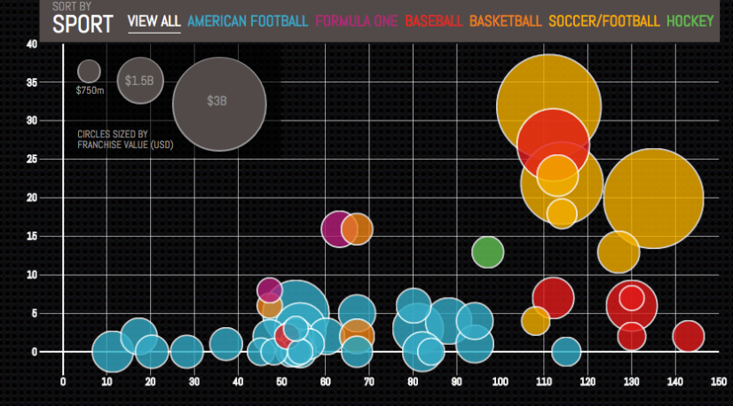

https://blog.hubspot.com/marketing/great-data-visualization-examples The visual is #8 This is another sports visual which I always find interesting to look at. This visual does a good job with the color-coding. It also does a good job of explaining how the bigger the circle the more value a francchise has. I do have a problem with the lack of axis labels and what the numbers on each axis represent, the story has to explain it.

## Visual 4

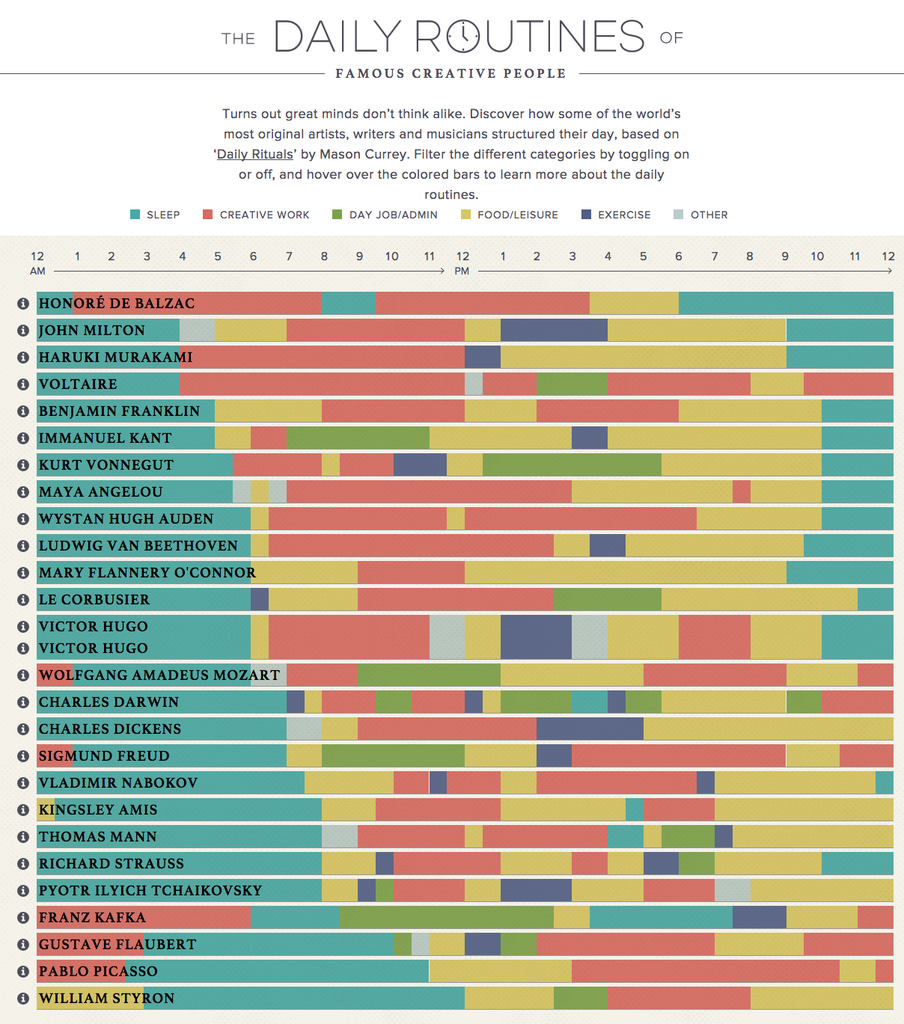

## Visual 5

[figure not shown]

https://blog.hubspot.com/marketing/great-data-visualization-examples The visual #13 These visuals always intrigue me mainly due to showing just how large some things are. It is nice that they use objects that everyday people are familiar (planes, ships, famous buildings). The graphic also does a good job of providing the measurements right next to the objects. The only thing that could be improved is not making the visual so long and skinny, maybe they could stack the objects next to each other in a bar graph sort of fashion.